# Homework1

Merve Unal - IE582 - Fall 2018 - 2016702108

**1. Introduction**

In this first assignment, i would like to share with you the answers of 2 tasks.

- The a option of first task contains 10 plots for each bookmakers and their initial and final odds. I choose 5 bookmakers, which are Pinnacle, Unibet,ComeOn, SBOBET, bet-at-home. I will share the codes of the bookmaker “Pinnacle” ’s initial odds. For the others the only thing i did is to change the names of bookmakers in the code section. Also, when i want to find the final ones, i converted my initial codes into final ones.
- The b option of first task contains 3 different plots. what it differentiates from each other is the range. The first thing i did in this section is plot the graph by choosing cutpoints as 0.1. However, when I did it as 0.1, the points were not distributed as i want to create. Since some points are quite far from each other and the number of these points are not enough. So i combine the ranges and create (0,0.2], (0.2,0.4],(0.4,0.6],(0.6,0.8],(0.8,1.00] Also, i chose the bookmaker “bet-at-home” in this particular section.
- In the second task, i chose the bookmaker “Pinnacle” and the odd type “1X2”. I plotted 3 different graphs for Home win, Away win and Draw win, seperately. One of which is comparison of Final probability and Initial Probability of Home Win, another is comparion of Final probability and Initial Probability of Away Win and the other is Final probability and Initial Probability of Draw Win.

**2. Figures**

**First task**

**a)**

**i. For the bookmaker “Pinnacle” and “Initial” odds**

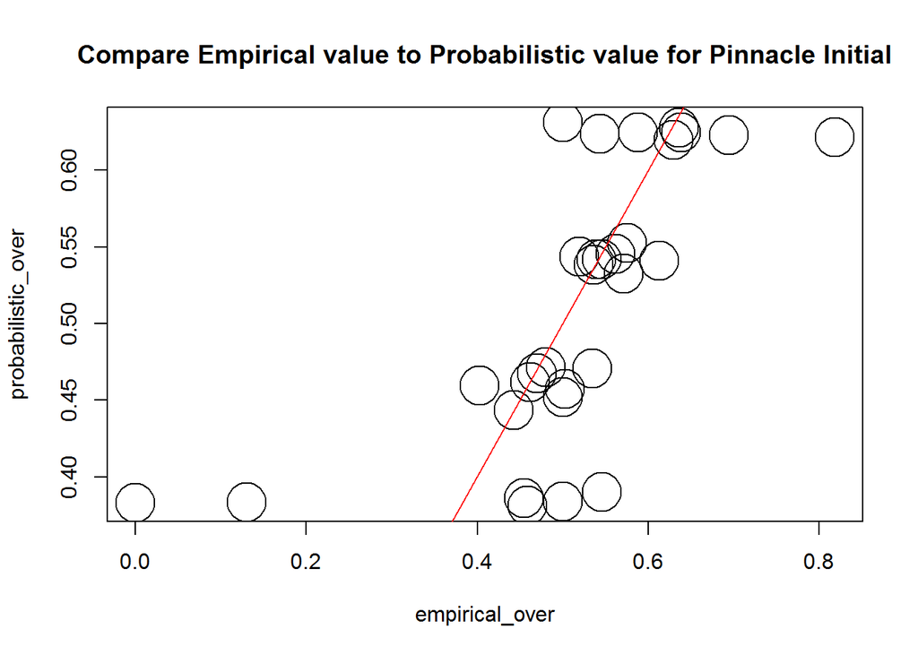

Figure 1 : Initial Empirical Over and Probabilistic Over Values For the bookmaker “Pinnacle”

As can be seen on the graph, mostly the points are distributed on the line y=x. What we want to do at the end of the day is to reach the target, which can be represented as y=x line. Actually, i created cutpoints as 0.05 at first. But then, i saw that in some ranges number of N is 1 or 2. Due to the fact that it is not much enough and it is not significant number enough, i extended my cutpoints range as 0.1.

**ii. For the bookmaker “Pinnacle” and “Final” odds**

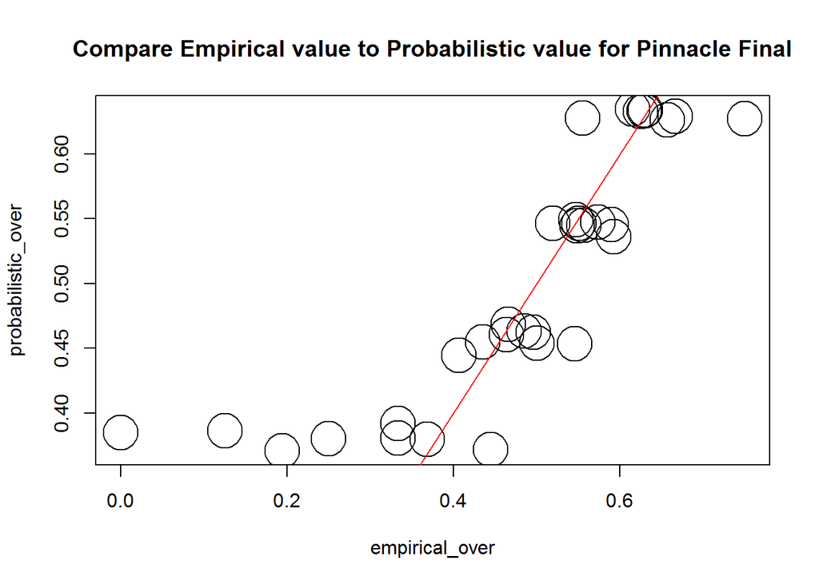

Figure 2 : Final Empirical Over and Probabilistic Over Values For the bookmaker “Pinnacle”

If we want to say the bookmaker is successful, we should see the points on the red line as much as possible. Since the target is to predict probabilistic one as much as close to empirical one. As can be seen on the graph, mostly the points are distributed on the line y=x. However, there are some points out of the line. But generally when i take a look at initial and final graph of “Pinnacle”, i can say that the bookmaker is successful enough. Furthermore, created cutpoints as 0.05 at first. But then, i saw that in some ranges number of N is 3 or 5. Due to the fact that it is not much enough and it is not significant number enough, i extended my cutpoints range as 0.1. If i want the compare Initial and final plot of the bookmaker “Pinnacle”, actually there is nothing so changing. Generally, Pinnacle is a good estimator determining probabilities.

**iii. For the bookmaker “Unibet” and “Initial” odds**

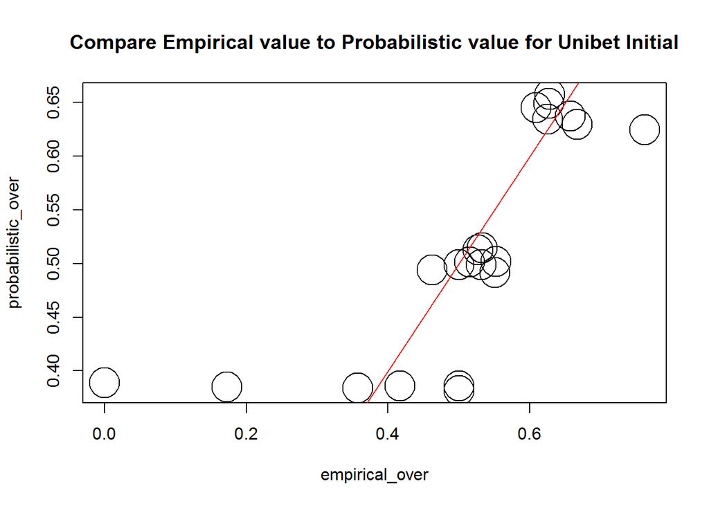

Figure 3 : Initial Empirical Over and Probabilistic Over Values For the bookmaker “Unibet”

Empirical one is real. However, probabilistic one shows whether or not bookmaker define a successful odd. i created cutpoints as 0.05 at first. But then, i saw that in N values of almost 20% of data is under 10.Due to the fact that it is not much enough and it is not significant number enough, i extended my cutpoints range as 0.1. But the problem did not change so i extended cutpoints range as 0.2. Then the problem was solved. As can be seen on the graph, most points are distributed on the line.

**iv. For the bookmaker “Unibet” and “Final” odds**

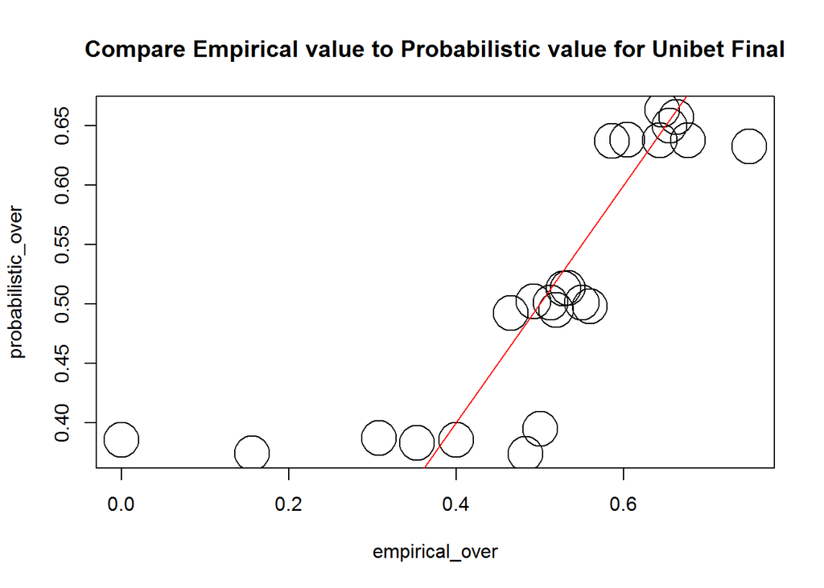

Figure 4: Final Empirical Over and Probabilistic Over Values For the bookmaker “Unibet”

Empirical one is real.However, probabilistic one shows whether or not bookmaker define a successful odd. I created cutpoints as 0.1 at first. But then, number of N values in this particular range is 3,4,5. Due to the fact that it is not much enough and it is not significant number enough, i extended my cutpoints range as 0.2. Then the problem was solved. As can be seen on the graph, most points are distributed on the line. However, the initial predictions of the bookmaker is more successful and consistent than the final predictions of the bookmaker. In other words, the prediction is more fluctuated in final prediction.

**v. For the bookmaker “ComeOn” and “Initial” odds**

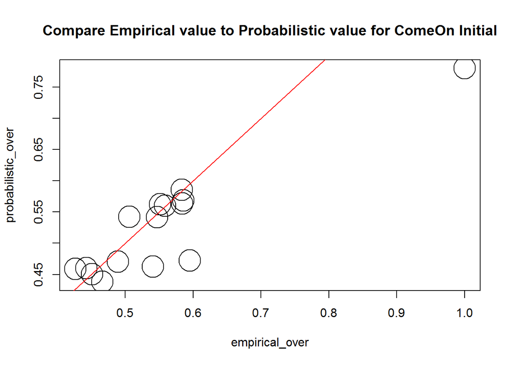

Figure 5: Initial Empirical Over and Probabilistic Over Values For the bookmaker “ComeOn”

Empirical one is real. However, probabilistic one shows whether or not bookmaker define a successful odd. i created cutpoints as 0.05,0.1,0.2, respectively. Butnumber of N values in this particular range is 3,4,5 for all of them. Due to the fact that it is not much enough and it is not significant number enough, i extended my cutpoints range as 0.25. Then the problem was solved. As can be seen on the graph, most points are distributed on the line.

**vi. For the bookmaker “ComeOn” and “Final” odds**

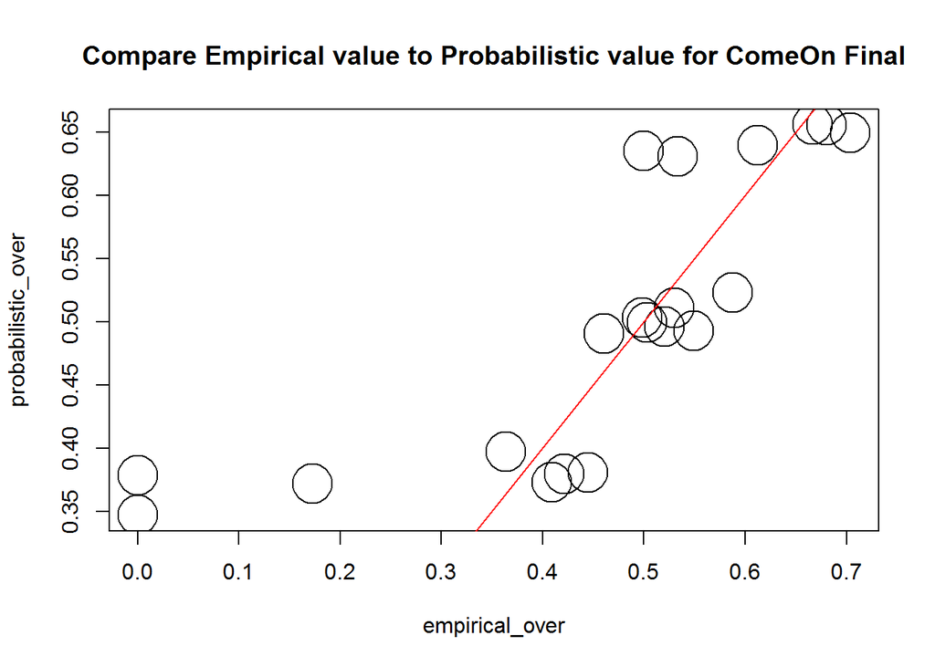

Figure 6: Final Empirical Over and Probabilistic Over Values For the bookmaker “ComeOn”

Empirical one is real. However, probabilistic one shows whether or not bookmaker define a successful odd. i created cutpoints as 0.05,0.1, respectively. But number of N values in this particular range is 3,4,5 for all of the cutpoints. Due to the fact that it is not much enough and it is not significant number enough, i extended my cutpoints range as 0.2. Then the problem was solved. As can be seen on the graph, most points are distributed on the line. However, as can be seen on the Figure 5, namely the initial one, the values are more consistent than the final one. In other words, in the final graph, the points are a bit more fluctuated and there are some points situated out of the y=x line.

**vii. For the bookmaker “SBOBET” and “Initial” odds**

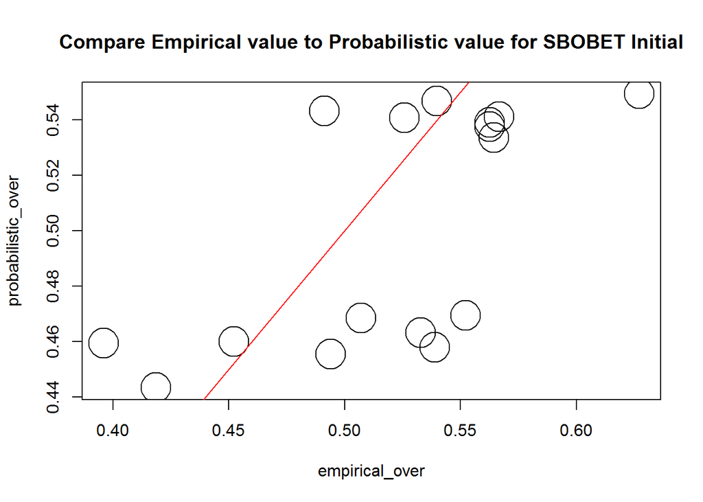

Figure 7: Initial Empirical Over and Probabilistic Over Values For the bookmaker “SBOBET”

Empirical one is real.However, probabilistic one shows whether or not bookmaker define a successful odd. I created cutpoints as 0.1,0.2, respectively. But number of N values in this particular range is so low numerically for all of the cutpoints. Due to the fact that it is not much enough and it is not significant number enough, i extended my cutpoints range as 0.25. Then the problem was solved. As can be seen on the graph, most points are distributed out of the line. Therefore, i can say that this bookmaker is not successful enough. Generally empirical over value is higher than probabilistic over value. In other words, this bookmaker defined over probability much lower. But in reality it is more than the bookmaker expected.

**viii. For the bookmaker “SBOBET” and “Final” odds**

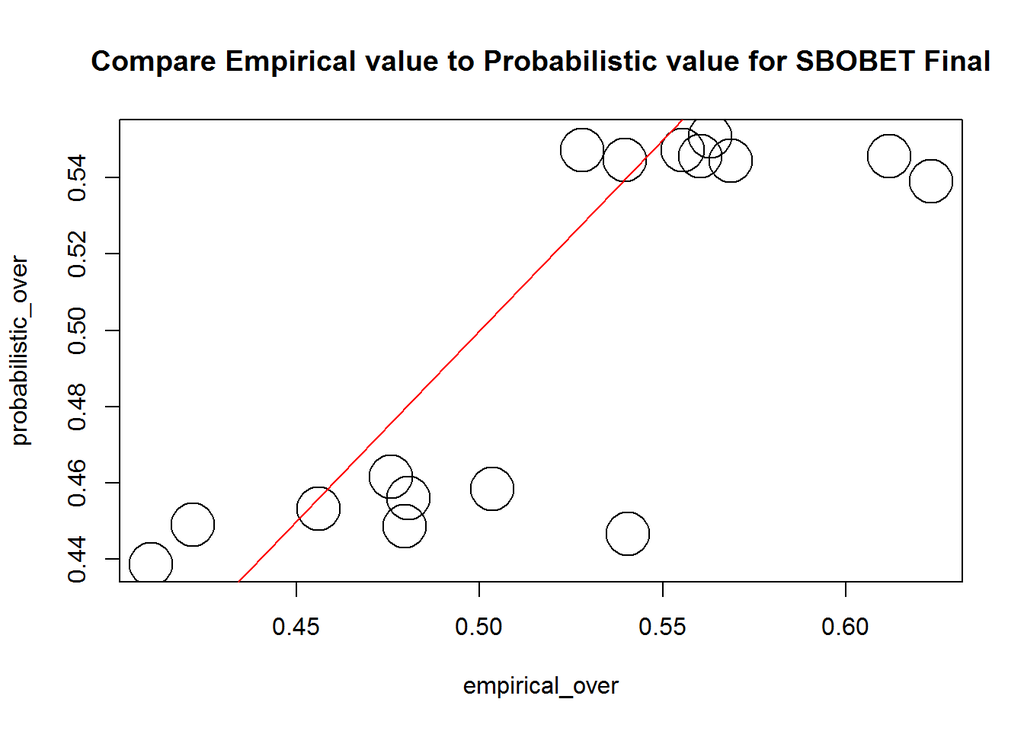

Figure 8: Final Empirical Over and Probabilistic Over Values For the bookmaker “SBOBET”

Empirical one is real. However, probabilistic one shows whether or not bookmaker define a successful odd. i created cutpoints as 0.1,0.2, respectively. But number of N values in this particular range is so low numerically for all of the cutpoints. Due to the fact that it is not much enough and it is not significant number enough, i extended my cutpoints range as 0.25. Then the problem was solved. As can be seen on the graph, most points are distributed out of the line. Therefore, i can say that this bookmaker is not successful enough.However, when i compared final values to initial values, the bookmaker’s prediction is a bit more close to empirical value. So, the bookmaker is more successful for defining final values than initial values.

**ix. For the bookmaker “bet-at-home” and “Initial” odds**

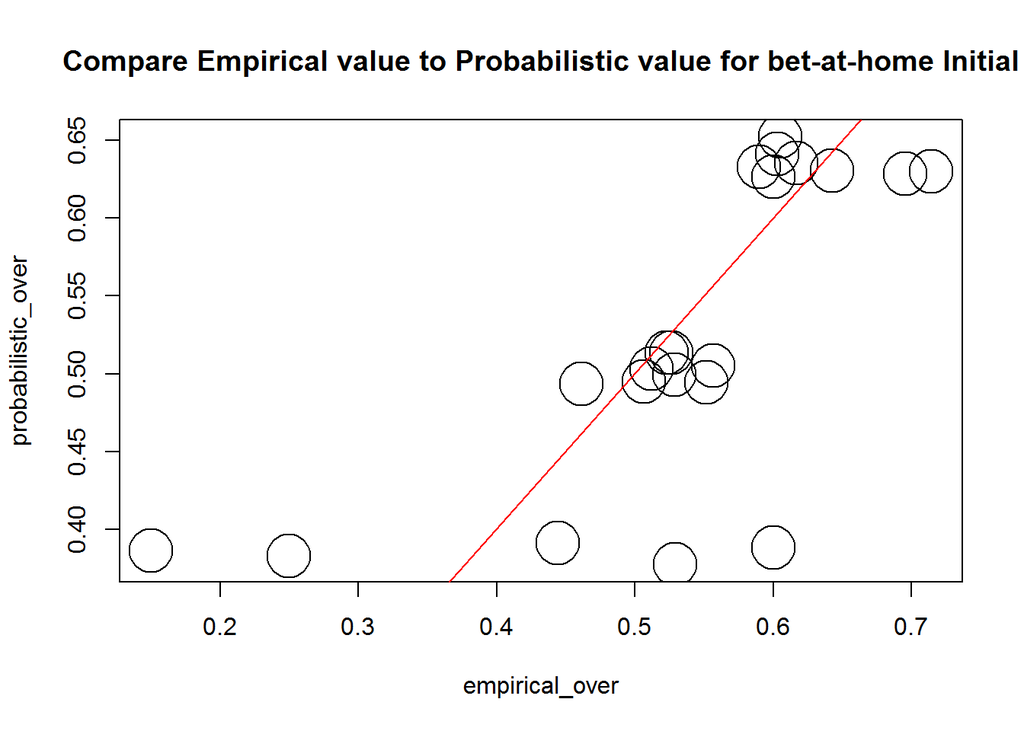

Figure 9: Initial Empirical Over and Probabilistic Over Values For the bookmaker “bet-at-home”

Empirical one is real. However, probabilistic one shows whether or not bookmaker define a successful odd. I created cutpoints as 0.1. But number of N values in this particular range is so low numerically. Due to the fact that it is not much enough and it is not significant number enough, i extended my cutpoints range as 0.2. Then the problem was solved. As can be seen on the graph, most points are distributed on the line. Therefore, i can say that this bookmaker is successful enough.

**x. For the bookmaker “bet-at-home” and “Final” odds**

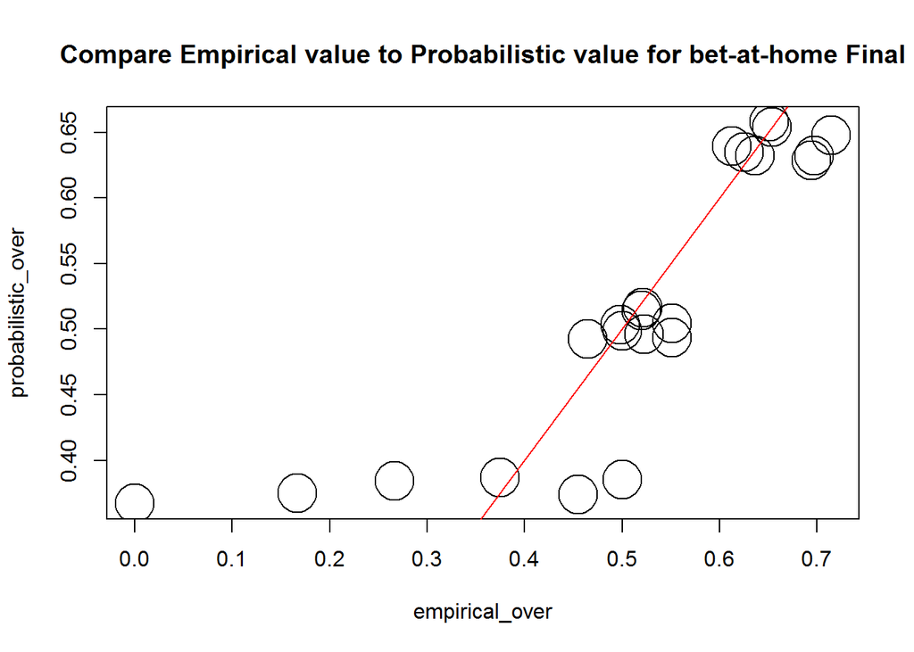

Figure 10: Final Empirical Over and Probabilistic Over Values For the bookmaker “bet-at-home”

Empirical one is real. However, probabilistic one shows whether or not bookmaker define a successful odd. I created cutpoints as 0.1. But number of N values in this particular range is so low numerically. Due to the fact that it is not much enough and it is not significant number enough, i extended my cutpoints range as 0.2. Then the problem was solved. As can be seen on the graph, most points are distributed on the line. However, there are also some points out of the line. When i compare initial graph of this bookmaker to final graph of this bookmaker, i can say that initial one is more successful than final one. Since in initial one most points were on the line. So i reckon the success of this bookmaker reduced as time goes on (from initial to final)

**b)**

I want to evaluate initial empirical and probabilistic value & final empirical and probabilistic value seperately in order to understand whether or not the bookmaker is consistently good at determining “over” probabilities during the given time period.

**i. For the bookmaker “bet-at-home” Initial Empirical and Probabilistic value**

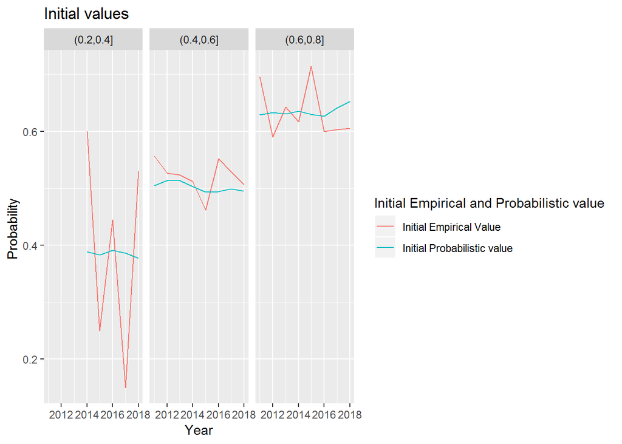

Figure 11: Initial Empirical and Probabilistic Value of the bookmaker “bet-at-home”

- What i want to expect is to see probabilistic over and empirical over as much as close to each other. In other words, as the distance between them is getting less, the level of predicting quality increased for this bookmaker.
- For instance, for the range “(0.2,0.4]”, namely in the first graph, in 2014 the gap is so much. The bookmaker did not determine own values right. Then, the gap is a bit reduced over the years. However, the gap is beginning to increase after 2016. In 2018, the empirical value is 0.52 and the probabilistic value is 0.37. The points that i mentioned are on the first graph’s last extreme points as you see. The bookmaker prediction is higher than probabilistic value. For the first range’s fluctuation is so much. But the fluctuation is not because of the bookmaker’s prediction. Actually, in reality the results are fluctuated. Yet, the fluctuation was not taken into account by the bookmaker when the bookmaker determines own prediction.Therefore the distance between these values are quite much.For the range “(0.4,0.6]” and the year “2018”, the gap between these values are getting less.
- For the range “(0.4,0.6]”, namely in the second graph, in 2011 the gap between these values are a bit far from each other. After 2012 the values are quite close to each other, which represents the quality of prediction of the bookmaker. Although in 2016 the gap was increased, then it began decreasing.
- For the range “(0.6,0.8]”, namely in the third graph, in 2011 the gap between these values are a bit far from each other. After 2012 the values are quite close to each other, which represents the quality of prediction of the bookmaker. Although in 2015 the gap was increased, then it began decreasing. The bookmaker determining the probabilstic value does not want to take a risk. Since the blue line for each range plot is not so considerably low or high.

**ii. For the bookmaker “bet-at-home” Final Empirical and Probabilistic value**

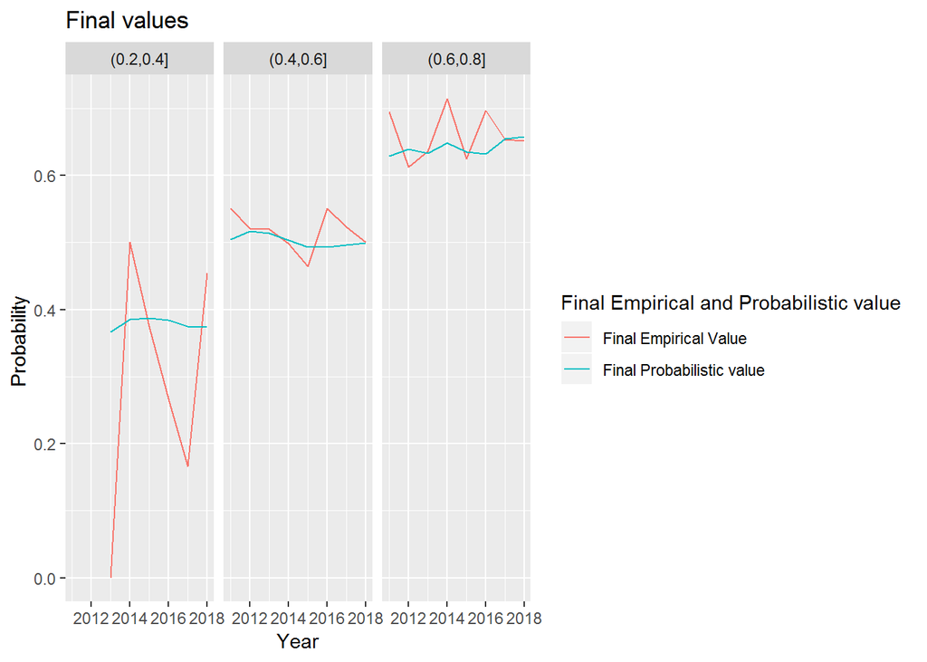

Figure 12: Final Empirical and Probabilistic Value of the bookmaker “bet-at-home”

**Second task**

I want to see 3 seperate graphs if there is any information in the odd changes. The first graph should be between initial home win(1) and final home win(1). The second graph should be between initial away win(2) and final away win(2).The third graph should be between initial draw win(X) and final draw win(X)

1. Home win Situation

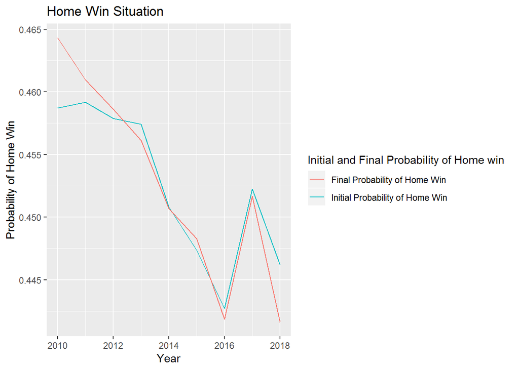

Figure 13: Initial and Final Probability of Home Win for the bookmaker “Pinnacle”

- The first graph represents the initial and final probability of home win. X axes is year, which is independent variable. y axes is Probability of home win, which is dependent variable. You can view the initial and final probabilities of the bookmaker “Pinnacle”. As can be seen on the graph, in 2010 the difference between initial and final probabilites determined by the bookmaker “Pinnacle” is quite high when i compared to the other years’ gap. In other words, in advance the bookmaker “Pinnacle” is not very consistent determining the probabilities. This bookmaker changed the probabilities at a significant rate in 2010. But then, especially after 2012, the gap reduced considerably as you can observe. Even from 2013 to 2017, the gap between initial and final probability of home win is almost zero. In 2018 the gap between final and initial probability of home win increases. Namely, the level of inconsistency between initial and final values goes up. Generally, when i observe this plot, i can say that the bookmaker is getting consistent over the years.
2. Away Win Situation

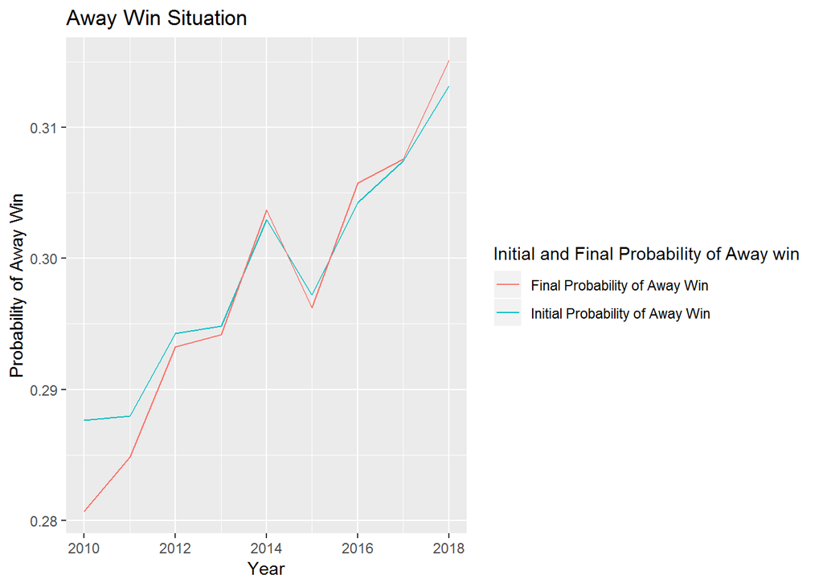

Figure 14: Initial and Final Probability of Away Win for the bookmaker “Pinnacle”

- The second graph represents the initial and final probability of away win. X axes is year, which is independent variable. y axes is Probability of away win, which is dependent variable. You can view the initial and final probabilities of the bookmaker “Pinnacle”. As can be seen on the graph, in 2010 the difference between initial and final probabilites determined by the bookmaker “Pinnacle” is quite high when i compared to the other years’ gap. In other words, in advance the bookmaker “Pinnacle” is not very consistent determining the probabilities of away win. But then, especially after 2011, the gap reduced considerably as you can observe. Even from 2013 to 2017, the gap interval between initial and final probability of away win is almost zero. In 2018 the gap interval between final and initial probability of away win began increased but a small number. Namely, the level of inconsistency between initial and final values goes up. Generally, when i observe this plot, i can say that the bookmaker is getting consistent over the years.
3. Draw Win Situation

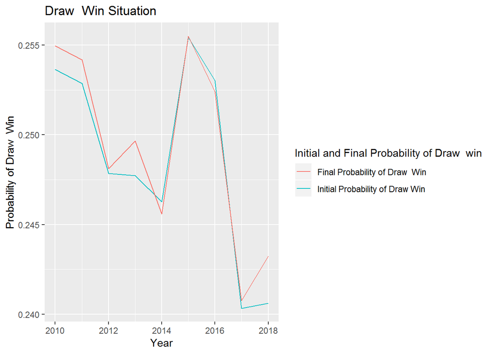

Figure 15: Initial and Final Probability of Draw Win for the bookmaker “Pinnacle”

**3. Appendix**

**a)Appendix1:First Task:Option a**

**i. Codes of Section i**

matches=unique(matches)

matches[ ,match_date := anydate(date)]

matches[ ,match_time := anytime(date)]

matches[,c(“HomeGoals”,“AwayGoals”):=tstrsplit(score,‘:’)]

matches=matches[complete.cases(matches)]

matches[,c(“HomeGoals”,“AwayGoals”):=tstrsplit(score,‘:’)]

matches[,HomeGoals:=as.numeric(HomeGoals)]

matches[,AwayGoals:=as.numeric(AwayGoals)]

matches[,TotalGoals:=HomeGoals+AwayGoals]

matches[,IsOver:=0]

matches[TotalGoals>2,IsOver:=1]

odds=unique(odds)

odds[ ,match_date := anydate(date)]

odds[ ,match_time := anytime(date)]

odds_ov_un=odds[betType==‘ou’ & totalhandicap==‘2.5’]

odds_ov_un[,totalhandicap:=NULL]

odds_ov_un=odds_ov_un[order(matchId, oddtype,bookmaker,date)]

odds_ov_un_initial=odds_ov_un[,list(start_odd=odd[1]), by=list(matchId,oddtype,bookmaker)]

odds_ov_un_final=odds_ov_un[,list(final_odd=odd[.N]),by=list(matchId,oddtype,bookmaker)]

odds=odds[complete.cases(odds)]

wide_odds_initial=dcast(odds_ov_un_initial,matchId~oddtype+bookmaker,value.var=‘start_odd’)

Pinnacle_over_under_initial=odds_ov_un_initial[bookmaker==‘Pinnacle’]

Pinnacle_wide_initial=dcast(Pinnacle_over_under_initial,matchId~oddtype,value.var=‘start_odd’)

matches[,Year:=year(match_time)]

merged_matches_initial_Pinnacle=merge(matches,Pinnacle_wide_initial,by=‘matchId’)

merged_matches_initial_Pinnacle[,probOver:=1/over]

merged_matches_initial_Pinnacle[,probUnder:=1/under]

merged_matches_initial_Pinnacle[,totalProb:=probOver+probUnder]

merged_matches_initial_Pinnacle[,probOver:=probOver/totalProb]

merged_matches_initial_Pinnacle[,probUnder:=probUnder/totalProb]

merged_matches_initial_Pinnacle=merged_matches_initial_Pinnacle[complete.cases(merged_matches_initial_Pinnacle)]

merged_matches_initial_Pinnacle[,totalProb:=NULL]

cutpoints=seq(0,1,0.1)

merged_matches_initial_Pinnacle[,odd_cut_over:=cut(probOver,cutpoints)]

merged_matches_initial_Pinnacle[,odd_cut_under:=cut(probUnder,cutpoints)]

summary_table_initial_Pinnacle=merged_matches_initial_Pinnacle[,list(empirical_over=mean(IsOver),probabilistic_over=mean(probOver),.N),by=list(Year,odd_cut_over)]

summary_table_initial_Pinnacle=summary_table_initial_Pinnacle[order(Year)]

plot(summary_table_initial_Pinnacle[,list(empirical_over,probabilistic_over)],cex=4,main=“Compare Empirical value to Probabilistic value for Pinnacle Initial”)

abline(0,1,col=‘red’)

**ii. Codes of Section ii,iii,iv,v,vi,vii,viii,ix,x**

The only thing i did is to change the names of bookmakers in the code section. Also,i converted my initial codes into final ones in order to find the final ones. Therefore, i will not share the codes of each of them as you said.

**b)Appendix2:First Task:Option b**

**i.For the bookmaker “bet-at-home” Initial Empirical and Probabilistic value**

cutpoints=seq(0,1,0.2)

merged_matches_initial_betathome[,odd_cut_over:=cut(probOver,cutpoints)]

summary_table_initial_betathome=merged_matches_initial_betathome[,list(empirical_over=mean(IsOver),probabilistic_over=mean(probOver),.N),by=list(Year,odd_cut_over)]

summary_table_initial_betathome=summary_table_initial_betathome[order(Year)]

**ii.For the bookmaker “bet-at-home” Final Empirical and Probabilistic value**

The only thing i did is to convert my initial codes into final ones in order to find the final ones. The rest is the same.

Therefore, i will not share the codes of it as you said.

**c)Appendix3:Second Task**

**First Section of Second Task**

odds<-odd_details_file_path

odds_1_2=odds[betType==‘1x2’]

odds_1_2=unique(odds_1_2)

odds[ ,match_date := anydate(date)]

odds[ ,match_time := anytime(date)]

odds_1_2[,totalhandicap:=NULL]

odds_1_2=odds_1_2[order(matchId, oddtype,bookmaker,date)]

odds_1_2_initial=odds_1_2[,list(start_odd=odd[1]), by=list(matchId,oddtype,bookmaker)]

wide_odds_1_2_initial=dcast(odds_1_2_initial,matchId~oddtype+bookmaker,value.var=‘start_odd’)

Pinnacle_1_2_initial=odds_1_2_initial[bookmaker==‘Pinnacle’]

Pinnacle_wide_initial_1_2=dcast(Pinnacle_1_2_initial,matchId~oddtype,value.var=‘start_odd’)

matches[,Year:=year(match_time)]

merged_matches_initial_Pinnacle_1_2=merge(matches,Pinnacle_wide_initial_1_2,by=‘matchId’)

merged_matches_initial_Pinnacle_1_2[,prob_1:=1/odd1]

merged_matches_initial_Pinnacle_1_2[,prob_2:=1/odd2]

merged_matches_initial_Pinnacle_1_2[,prob_X:=1/oddX]

merged_matches_initial_Pinnacle_1_2[,totalProb_1x2:=prob_1+prob_2+prob_X]

merged_matches_initial_Pinnacle_1_2

merged_matches_initial_Pinnacle_1_2[,prob_1:=prob_1/totalProb_1x2]

merged_matches_initial_Pinnacle_1_2[,prob_2:=prob_2/totalProb_1x2]

merged_matches_initial_Pinnacle_1_2[,prob_X:=prob_X/totalProb_1x2]

merged_matches_initial_Pinnacle_1_2

merged_matches_initial_Pinnacle_1_2[,totalProb_1x2:=NULL]

merged_matches_initial_Pinnacle_1_2=merged_matches_initial_Pinnacle_1_2[order(Year)]

merged_matches_initial_Pinnacle_1_2[,Home_win:=ifelse(HomeGoals>AwayGoals,1,0)]

merged_matches_initial_Pinnacle_1_2[,Away_win:=ifelse(HomeGoals<AwayGoals,1,0)]

merged_matches_initial_Pinnacle_1_2[,Draw_win:=ifelse(HomeGoals==AwayGoals,1,0)]

odds_1_2_final=odds_1_2[,list(final_odd=odd[.N]),by=list(matchId,oddtype,bookmaker)]

wide_odds_1_2_final=dcast(odds_1_2_final,matchId~oddtype+bookmaker,value.var=‘final_odd’)

Pinnacle_1_2_final=odds_1_2_final[bookmaker==‘Pinnacle’]

Pinnacle_wide_final_1_2=dcast(Pinnacle_1_2_final,matchId~oddtype,value.var=‘final_odd’)

matches[,Year:=year(match_time)]

merged_matches_final_Pinnacle_1_2=merge(matches,Pinnacle_wide_final_1_2,by=‘matchId’)

merged_matches_final_Pinnacle_1_2[,prob_1:=1/odd1]

merged_matches_final_Pinnacle_1_2[,prob_2:=1/odd2]

merged_matches_final_Pinnacle_1_2[,prob_X:=1/oddX]

merged_matches_final_Pinnacle_1_2[,totalProb_1x2:=prob_1+prob_2+prob_X]

merged_matches_final_Pinnacle_1_2

merged_matches_final_Pinnacle_1_2[,prob_1:=prob_1/totalProb_1x2]

merged_matches_final_Pinnacle_1_2[,prob_2:=prob_2/totalProb_1x2]

merged_matches_final_Pinnacle_1_2[,prob_X:=prob_X/totalProb_1x2]

merged_matches_final_Pinnacle_1_2

merged_matches_final_Pinnacle_1_2[,totalProb_1x2:=NULL]

merged_matches_final_Pinnacle_1_2=merged_matches_final_Pinnacle_1_2[order(Year)]

merged_matches_final_Pinnacle_1_2[,Home_win:=ifelse(HomeGoals>AwayGoals,1,0)]

merged_matches_final_Pinnacle_1_2[,Away_win:=ifelse(HomeGoals<AwayGoals,1,0)]

merged_matches_final_Pinnacle_1_2[,Draw_win:=ifelse(HomeGoals==AwayGoals,1,0)]

summary_table_merged_matches_final_Pinnacle_1_2=merged_matches_final_Pinnacle_1_2[,list(empirical_home_win=mean(Home_win),empirical_away_win=

mean(Away_win),empirical_draw_win=mean(Draw_win),prob_1=mean(prob_1),prob_2=mean(prob_2),prob_X=mean(prob_X),.N),by=list(Year)]

ggplot(summary_table_merged_matches_initial_Pinnacle_1_2,aes(x=Year,y=prob_1))+geom_line(data=summary_table_merged_matches_initial_Pinnacle_1_2,aes(color=“Initial Probability of Home Win”))+ geom_line(data=summary_table_merged_matches_final_Pinnacle_1_2,aes(color=“Final Probability of Home Win”)) + labs(color=“Initial and Final Probability of Home win”) + ylab(“Probability of Home Win”) + ggtitle(“Home Win Situation”)

**Second and Third Section of Second Task**

Everything is the same. The only thing you should transform is prob_1 into prob_2 and prob_X in ggplot, respectively. Therefore, i did not share the others’ codes.